# ggplot2 live coding script

Matt Eldridge

Last modified: 09 Jun 2019

## Introduction

In this session we will use the popular **ggplot2** package to visualize data that has already been transformed into a tidy tabular format that is suitable for use in creating plots.

A tidy dataset is a data frame (or table) for which the following are true:

1. Each variable has its own column
2. Each observation has its own row
3. Each value has its own cell

### Load the tidyverse

Load the core packages from the *tidyverse*, including **ggplot2**.

```r
library(tidyverse)
```

*[**Instructors note:** draw attention to the packages that are loaded, relate these to this and other sections of the course.]*

#### Aside: function name conflicts (optional)

With the many hundreds of R packages available it is inevitable that there will be functions with the same name being used by more than one package.

For example, filter function in dplyr has masked filter function from the stats package that already loaded as part of base R.

```r
?filter
```

Navigate to each help section and show how the signatures differ and explain how using the one you hadn’t intended will likely cause your code to fail.

Use R studio’s file completion to show that the filter function we get by default.

To use the `filter` function from the `stats` package we need to include the `stats` namespace prefix as follows:

```r
stats::filter(presidents, rep(1, 3))
```

## The patients dataset

### Read in the patient data

Read in the patients data frame using `read_tsv` from the `readr` package.

```r
patients <- read_tsv("patient-data-cleaned.txt")
```

`read_tsv` imports tab-delimited files (tsv = tab-separated values).

There is an equivalent function in `readr` called `read_csv` for importing CSV files.

#### Aside: `readr` vs base R equivalents

Why use the `readr` functions compared with the more familiar `read.table`, `read.delim` and `read.csv` functions from base R?

- They are typically much faster (~10x) for large datasets
- They produce tibbles, which have much nicer printing and other advantages when chaining operations
- They do not convert character vectors to factors
- They do not change column names, e.g. where column names contain spaces or special characters

### Getting to know the patients dataset

Let’s have a look at the patients dataset before trying to visualize it.

View in RStudio by clicking on it in the Environment tab or by typing

```r
View(patients)
```

It is a special type of data frame called a tibble.

```r
class(patients)
```

```
## [1] "spec_tbl_df" "tbl_df"      "tbl"         "data.frame"
```

Printing a tibble shows each of the column types.

Print the patients data frame at the console.

```r
patients
```

```
## # A tibble: 100 x 15
##    ID    Name  Sex   Smokes Height Weight Birth      State Grade Died
##    <chr> <chr> <chr> <chr>   <dbl>  <dbl> <date>     <chr> <dbl> <lgl>
##  1 AC/A… Mich… Male  Non-S…   183.   76.6 1972-02-06 Geor…     2 FALSE
##  2 AC/A… Derek Male  Non-S…   179.   80.4 1972-06-15 Colo…     2 FALSE
##  3 AC/A… Todd  Male  Non-S…   169.   75.5 1972-07-09 New …     2 FALSE
##  4 AC/A… Rona… Male  Non-S…   176.   94.5 1972-08-17 Colo…     1 FALSE
##  5 AC/A… Chri… Fema… Non-S…   164.   71.8 1973-06-12 Geor…     2 TRUE
##  6 AC/A… Dana  Fema… Smoker   158.   69.9 1973-07-01 Indi…     2 FALSE
##  7 AC/A… Erin  Fema… Non-S…   162.   68.8 1972-03-26 New …     1 FALSE
##  8 AC/A… Rach… Fema… Non-S…   166.   70.4 1973-05-11 Colo…     1 FALSE
##  9 AC/A… Rona… Male  Non-S…   181.   76.9 1971-12-31 Geor…     1 FALSE
## 10 AC/A… Bryan Male  Non-S…   167.   79.1 1973-07-19 New …     2 FALSE
## # … with 90 more rows, and 5 more variables: Score <dbl>,
## #   Date.Entered.Study <date>, Age <dbl>, BMI <dbl>, Overweight <lgl>
```

This dataset required quite a bit of cleaning to get into the state where we can do some proper exploratory data analysis and visualization.

Later we will look at issues with real-world datasets and the need for cleaning these in the part of the course on tidying data and some of the tools in the tidyverse collection of packges that help in doing so.

Reminder: a “tidy” dataset in one in which

- each column is a variable
- each row is an observation

*What are the variables in the patients dataset?*

*What are the observations?*

*What types of variables do we have?*

```r
class(patients$Sex)
```

```
## [1] "character"
```

```r
class(patients$Height)
```

```
## [1] "numeric"
```

```r
class(patients$Overweight)
```

```
## [1] "logical"
```

*What types should each variable be?*

- Categorical: Sex, Smokes, State
- Continuous: Height, Weight, BMI

*Do any need to be changed?*

*What about Grade?*

- Categorial, but ordered, i.e. ordinal

*What about Age?*

- Certainly discrete in this dataset (only whole numbers), again we might want to treat these as ordinal

We also have some columns read in as logical and date variables. Logical variables are treated by ggplot2 as categorial.

Most of the time ggplot2 will treat variables in the way you’d hope, e.g. creating a bar plot showing the number of patients in each grade even though this is currently an integer. But sometimes it will cause problems so it’s a good idea to sort this sort of thing out right from the outset.

R uses a special type of variable called a factor to handle categorical values. Factors are variables that have a fixed and known set of possible values – these are referred to as the levels of a factor, e.g. Female and Male for the Sex variable in the patients dataset.

Let’s turn some of our columns that should be categorical variables into factors.

```r
patients$Sex <- factor(patients$Sex)
patients$Sex
```

```
##   [1] Male   Male   Male   Male   Female Female Female Female Male   Male
##  [11] Female Female Male   Female Female Male   Male   Male   Male   Male
##  [21] Male   Female Male   Female Female Male   Male   Male   Male   Male
##  [31] Female Male   Male   Female Male   Female Male   Female Male   Female
##  [41] Male   Female Female Female Female Female Female Female Male   Female
##  [51] Female Female Female Female Male   Female Female Female Male   Male
##  [61] Female Male   Female Male   Male   Female Male   Female Male   Female
##  [71] Female Male   Male   Female Male   Female Male   Male   Female Female
##  [81] Female Female Male   Female Female Female Female Male   Female Male
##  [91] Male   Male   Female Male   Female Female Female Female Female Female
## Levels: Female Male
```

```r
levels(patients$Sex)
```

```
## [1] "Female" "Male"
```

```r
patients
```

```
## # A tibble: 100 x 15
##    ID    Name  Sex   Smokes Height Weight Birth      State Grade Died
##    <chr> <chr> <fct> <chr>   <dbl>  <dbl> <date>     <chr> <dbl> <lgl>
##  1 AC/A… Mich… Male  Non-S…   183.   76.6 1972-02-06 Geor…     2 FALSE
##  2 AC/A… Derek Male  Non-S…   179.   80.4 1972-06-15 Colo…     2 FALSE
##  3 AC/A… Todd  Male  Non-S…   169.   75.5 1972-07-09 New …     2 FALSE
##  4 AC/A… Rona… Male  Non-S…   176.   94.5 1972-08-17 Colo…     1 FALSE
##  5 AC/A… Chri… Fema… Non-S…   164.   71.8 1973-06-12 Geor…     2 TRUE
##  6 AC/A… Dana  Fema… Smoker   158.   69.9 1973-07-01 Indi…     2 FALSE
##  7 AC/A… Erin  Fema… Non-S…   162.   68.8 1972-03-26 New …     1 FALSE
##  8 AC/A… Rach… Fema… Non-S…   166.   70.4 1973-05-11 Colo…     1 FALSE
##  9 AC/A… Rona… Male  Non-S…   181.   76.9 1971-12-31 Geor…     1 FALSE
## 10 AC/A… Bryan Male  Non-S…   167.   79.1 1973-07-19 New …     2 FALSE
## # … with 90 more rows, and 5 more variables: Score <dbl>,
## #   Date.Entered.Study <date>, Age <dbl>, BMI <dbl>, Overweight <lgl>
```

Rather than repeat the above line for each of several columns we can use the `mutate_at` function from `dplyr` to do this in a single operation. We will cover this later in the course.

```r
patients <- mutate_at(patients, vars(Sex, Smokes, State, Grade, Age), factor)
patients
```

```
## # A tibble: 100 x 15
##    ID    Name  Sex   Smokes Height Weight Birth      State Grade Died
##    <chr> <chr> <fct> <fct>   <dbl>  <dbl> <date>     <fct> <fct> <lgl>
##  1 AC/A… Mich… Male  Non-S…   183.   76.6 1972-02-06 Geor… 2     FALSE
##  2 AC/A… Derek Male  Non-S…   179.   80.4 1972-06-15 Colo… 2     FALSE
##  3 AC/A… Todd  Male  Non-S…   169.   75.5 1972-07-09 New … 2     FALSE
##  4 AC/A… Rona… Male  Non-S…   176.   94.5 1972-08-17 Colo… 1     FALSE
##  5 AC/A… Chri… Fema… Non-S…   164.   71.8 1973-06-12 Geor… 2     TRUE
##  6 AC/A… Dana  Fema… Smoker   158.   69.9 1973-07-01 Indi… 2     FALSE
##  7 AC/A… Erin  Fema… Non-S…   162.   68.8 1972-03-26 New … 1     FALSE
##  8 AC/A… Rach… Fema… Non-S…   166.   70.4 1973-05-11 Colo… 1     FALSE
##  9 AC/A… Rona… Male  Non-S…   181.   76.9 1971-12-31 Geor… 1     FALSE
## 10 AC/A… Bryan Male  Non-S…   167.   79.1 1973-07-19 New … 2     FALSE
## # … with 90 more rows, and 5 more variables: Score <dbl>,
## #   Date.Entered.Study <date>, Age <fct>, BMI <dbl>, Overweight <lgl>
```

## Our first ggplot - a scatter plot

First we’ll create a scatter plot of height vs weight.

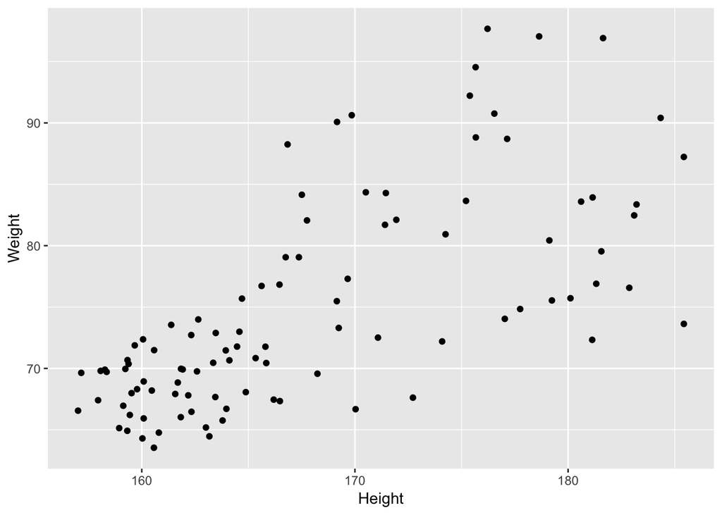

```r
ggplot(data = patients) +
  geom_point(mapping = aes(x = Height, y = Weight))
```

We specified 3 things to create this plot.

1. The data – needs to be a data frame
2. The type of plot – this is called a **geom** in ggplot2 terminology
3. The mapping of variables in the data to visual properties (called **aesthetics** in ggplot2) of objects in the plot

In this case the type of plot is a `geom_point`, ggplot2’s function for a scatter plot, and the height and weight variables are mapped to the x and y coordinates, i.e. the positions of points on the scatter plot.

Other aesthetics could include the size, shape and colour of those points.

Look up the `geom_point` help in RStudio.

```r
?geom_point
```

## Aesthetic mappings

In the `geom_point` help page scroll down to the aesthetics section to see what aesthetics are actually required (x and y).

What about those other aesthetics?

Colours are usually fun – let’s try to use a colour aesthetic.

We need to set a mapping of a variable to colour just like we did for x and y.

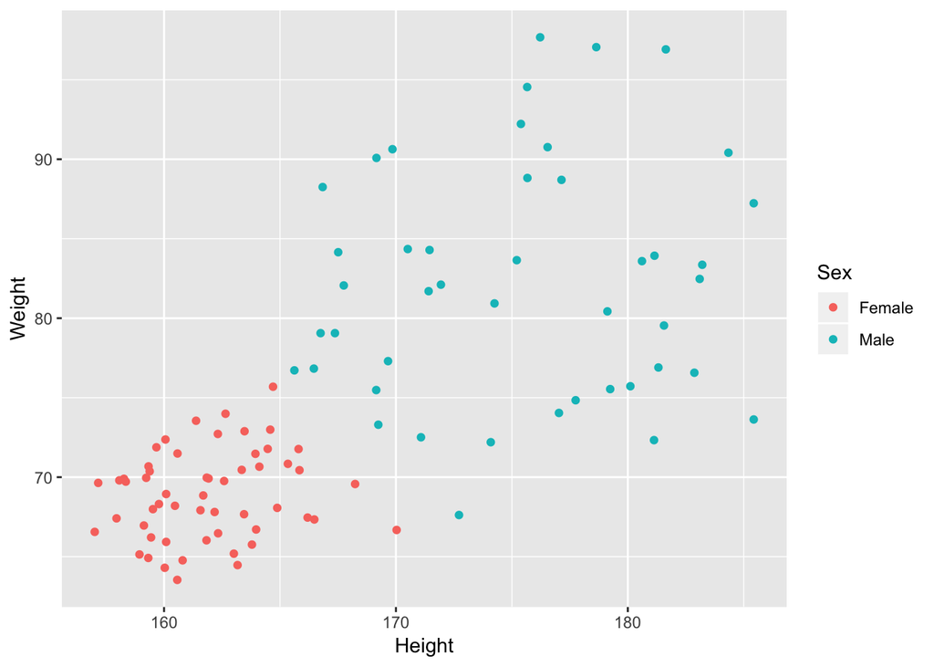

```r
ggplot(data = patients) +
  geom_point(mapping = aes(x = Height, y = Weight, colour = Sex))
```

What about colouring based on a continuous variable?

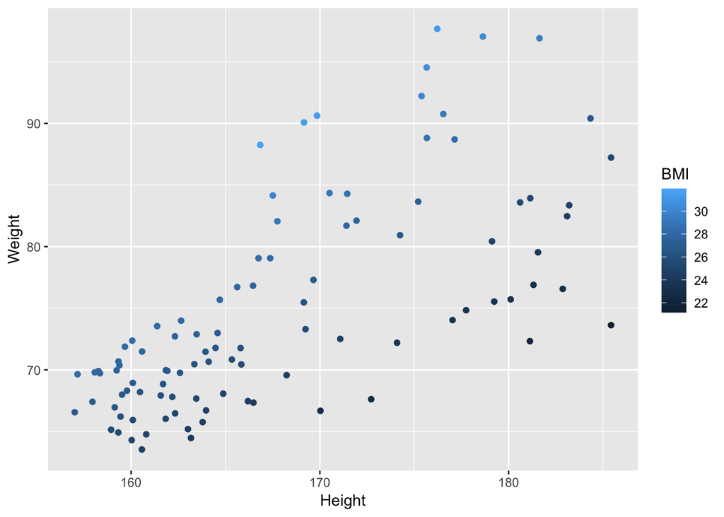

```r
ggplot(data = patients) +
  geom_point(mapping = aes(x = Height, y = Weight, colour = BMI))
```

Let’s try some of the other aesthetics.

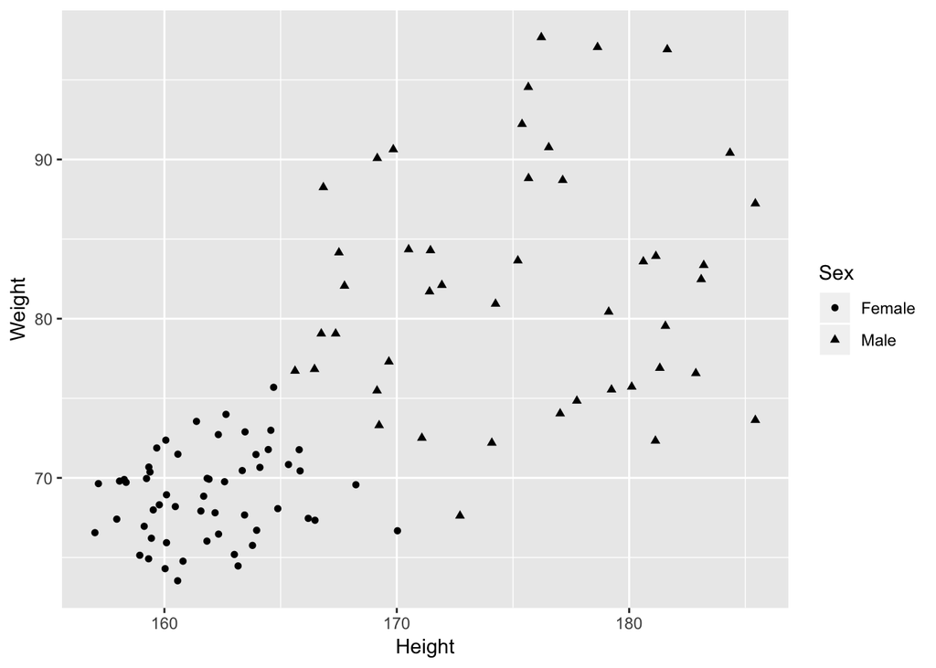

```r
ggplot(data = patients) +
  geom_point(mapping = aes(x = Height, y = Weight, shape = Sex))
```

Some aesthetics can only be used with categorical variables, e.g. shape.

```r
ggplot(data = patients) +
  geom_point(mapping = aes(x = Height, y = Weight, shape = BMI))
```

```
## Error: A continuous variable can not be mapped to shape
```

Not all aesthetics are useful, at least not for this plot.

```
## Warning: Using size for a discrete variable is not advised.
```

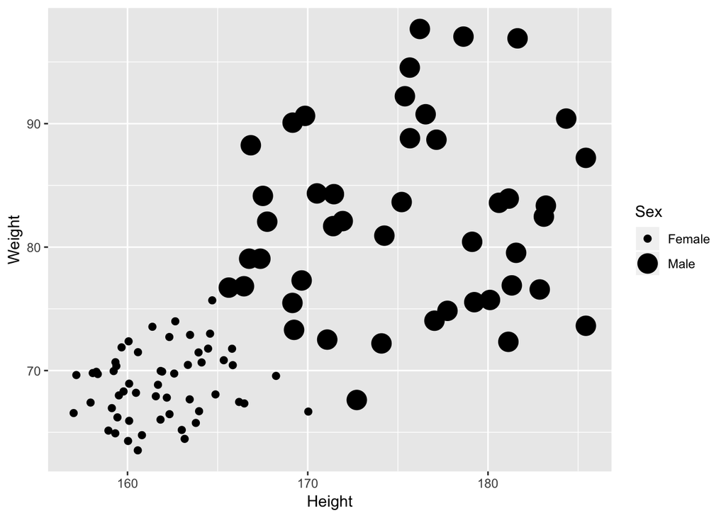

```r
ggplot(data = patients) +
  geom_point(mapping = aes(x = Height, y = Weight, size = Sex))
```

The warning hints that we should be using a continuous variable for size instead.

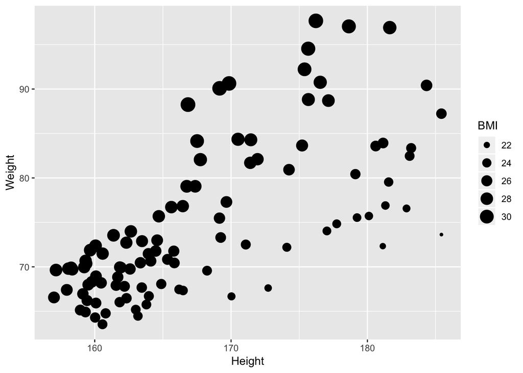

```r
ggplot(data = patients) +
  geom_point(mapping = aes(x = Height, y = Weight, size = BMI))
```

The transparency of the points can be set to reflect a variable using the `alpha` aesthetic.

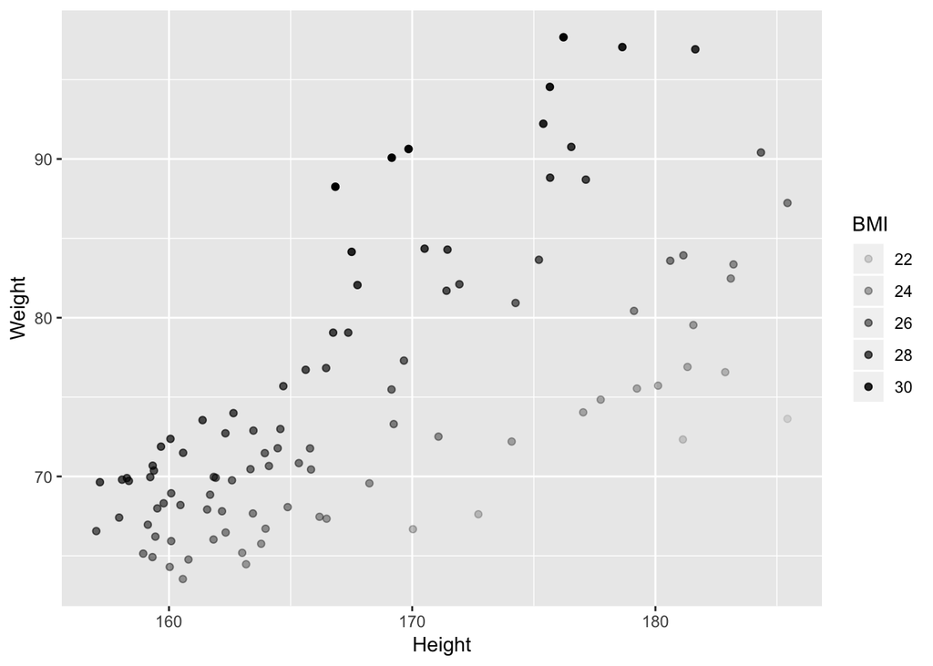

```r
ggplot(data = patients) +
  geom_point(mapping = aes(x = Height, y = Weight, alpha = BMI))
```

Colours are more commonly used than shapes, sizes or transparency.

Virtually every aspect of the plots we’ve created can be customized. We will learn how to change the colours used a bit later.

## ggplot2 grammer

The “gg” in ggplot2 stands for “grammar of graphics”. This grammar is a coherent system for describing and building graphs.

The basic template is:

```
ggplot(data = <DATA>) +
  <GEOM_FUNCTION>(mapping = aes(<MAPPINGS>))
```

This template can be used to create any of the different types of graph possible with ggplot2.

## Another plot type - bar chart

Look up ggplot2 package help in RStudio to see what other geoms are available (find the ggplot2 package in the Packages tab normally found in the bottom right hand corner).

Let’s create a bar chart of patient’s ages.

`geom_bar` is the geom we need and it requires a single aesthetic mapping of the categorical variable of interest to `x`.

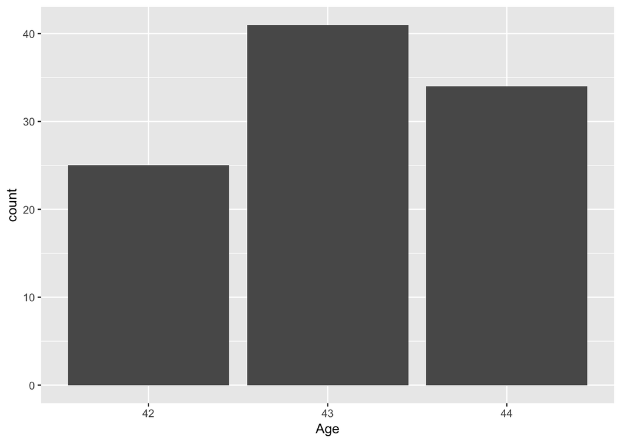

```r
ggplot(data = patients) +
  geom_bar(mapping = aes(x = Age))
```

The dark grey bars are a big ugly - what if we want each bar to be a different colour?

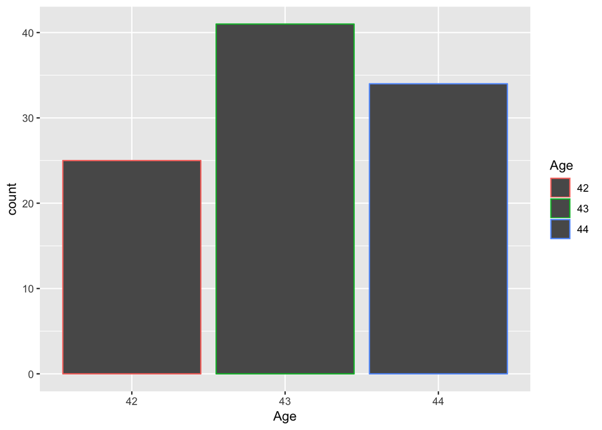

```r
ggplot(data = patients) +
  geom_bar(mapping = aes(x = Age, colour = Age))
```

Colouring the edges wasn’t quite what we had in mind. Look at the help for `geom_bar` to see what other aesthetic we should have used.

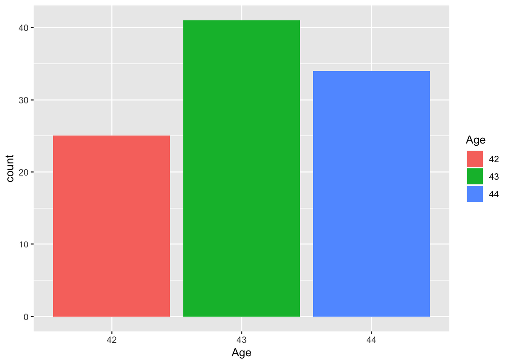

```r
ggplot(data = patients) +
  geom_bar(mapping = aes(x = Age, fill = Age))
```

What happens if we fill with something other than age, e.g. sex?

We get a stacked bar plot.

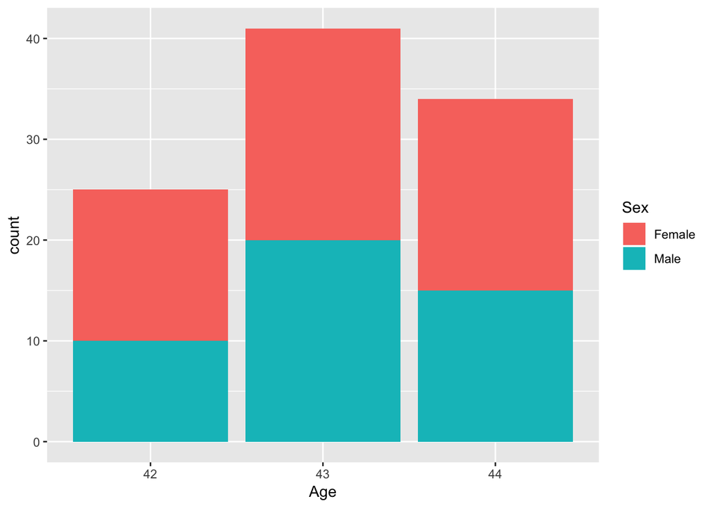

```r
ggplot(data = patients) +
  geom_bar(mapping = aes(x = Age, fill = Sex))
```

Note the similarity in what we did here to what we did with the scatter plot - there is a common grammar.

What if want all the bars to be the same colour but not dark grey, e.g. blue?

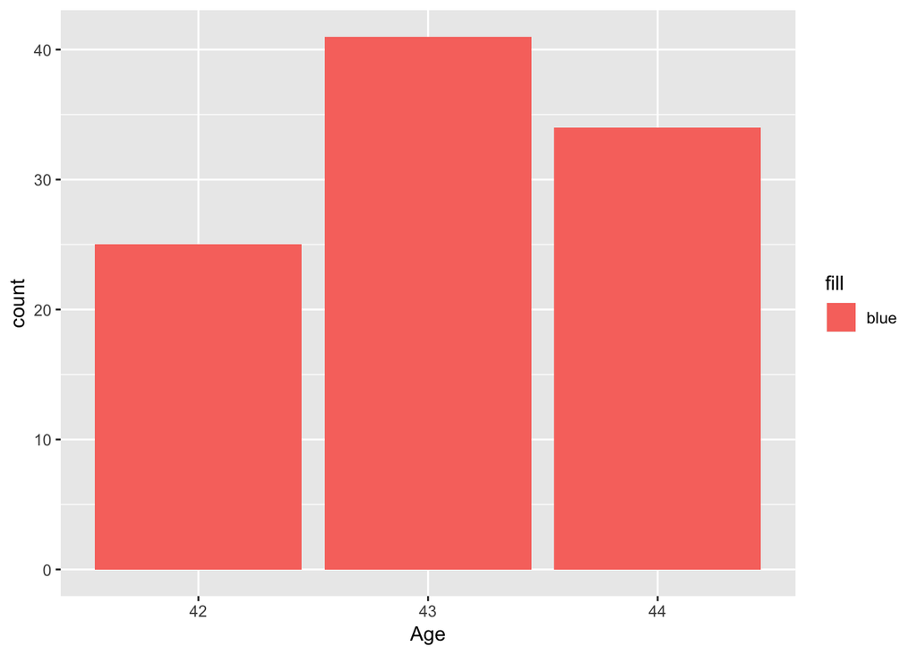

```r
ggplot(data = patients) +
  geom_bar(mapping = aes(x = Age, fill = "blue"))
```

That doesn’t look right - why not?

You can set the aesthetics to a fixed value but this needs to be outside the mapping.

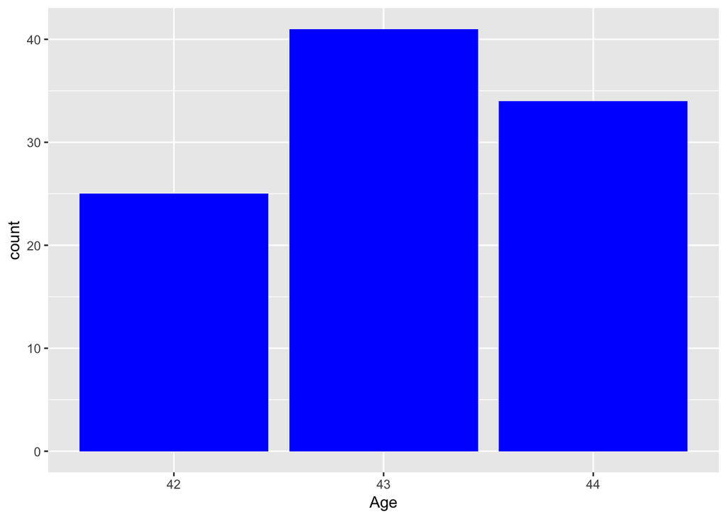

```r
ggplot(data = patients) +
  geom_bar(mapping = aes(x = Age), fill = "blue")
```

Setting this inside the `aes()` mapping told ggplot2 to map the colour aesthetic to some variable in the data frame that actually is a constant value “blue” for all observations.

## Multiple layers

Consider again the ggplot2 grammar:

```
ggplot(data = <DATA>) +
  <GEOM_FUNCTION>(mapping = aes(<MAPPINGS>))
```

Why do we have the ggplot part and geom part joined by a “+” symbol?

The ‘+’ operator has been overridden by ggplot2 to add layers and other components (scales, themes, etc.) to the plot.

We can have multiple geoms in the same plot. Each is a different layer.

Let’s create a plot with two geoms.

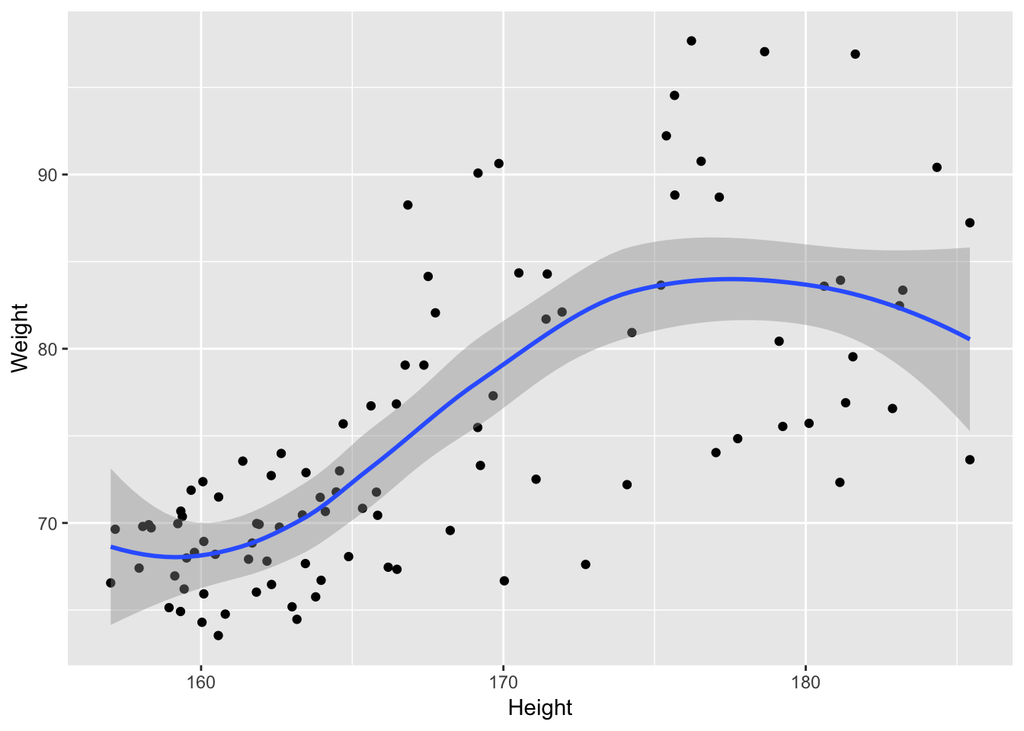

```r
ggplot(data = patients) +
  geom_point(mapping = aes(x = Height, y = Weight)) +
  geom_smooth(mapping = aes(x = Height, y = Weight))
```

What is geom_smooth doing? Look up the help page.

Note that the shaded area represents the standard error bounds on the fitted model.

There is some annoying duplication of code here. We can avoid this by putting the mappings in the `ggplot` function instead.

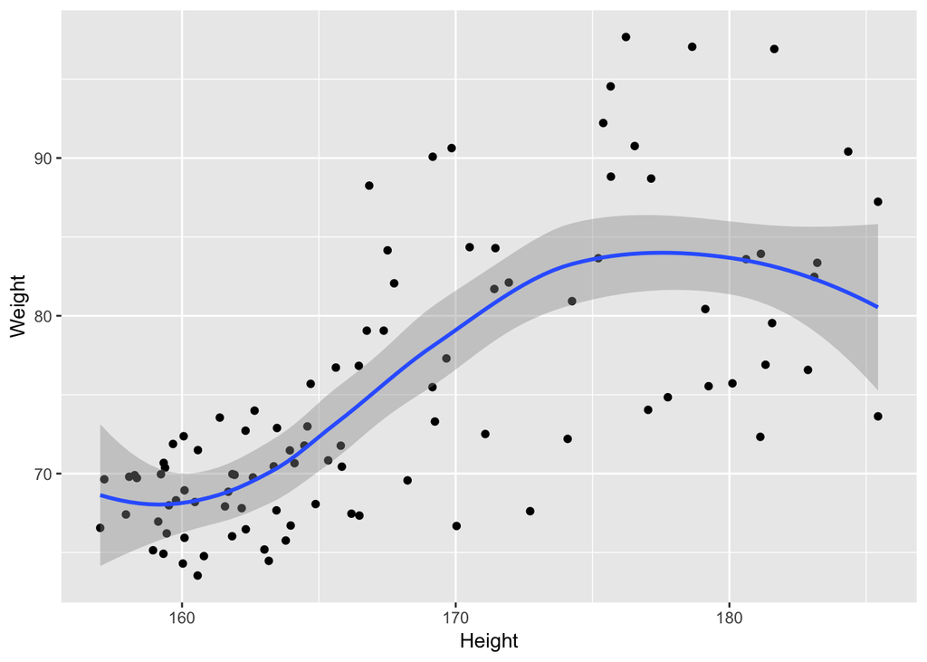

```r
ggplot(data = patients, mapping = aes(x = Height, y = Weight)) +
  geom_point() +
  geom_smooth()
```

Aesthetics set in the `ggplot` function are treated as global mappings for the plot and are inherited by all geoms added to the plot.

Let’s say we still want to colour the points by sex.

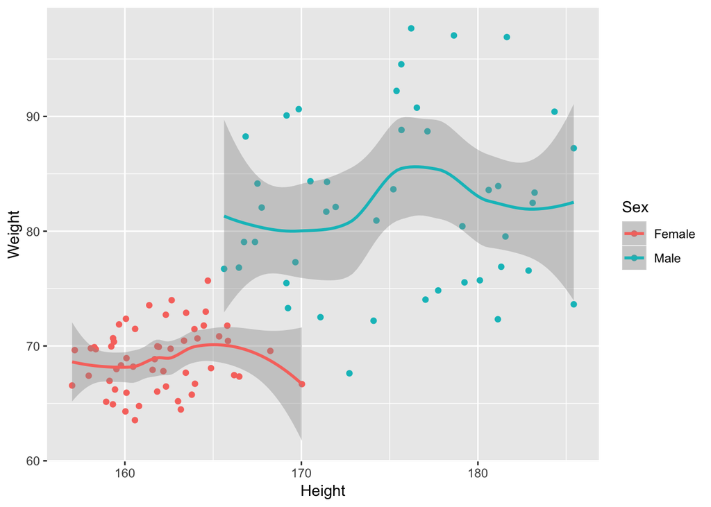

```r
ggplot(data = patients, mapping = aes(x = Height, y = Weight, colour = Sex)) +
  geom_point() +
  geom_smooth()
```

Well, that wasn’t expected, although it’s pretty neat. We only wanted to apply the colour aesthetic to the points.

We can add to the aesthetics in the geom function to apply them just to that geom.

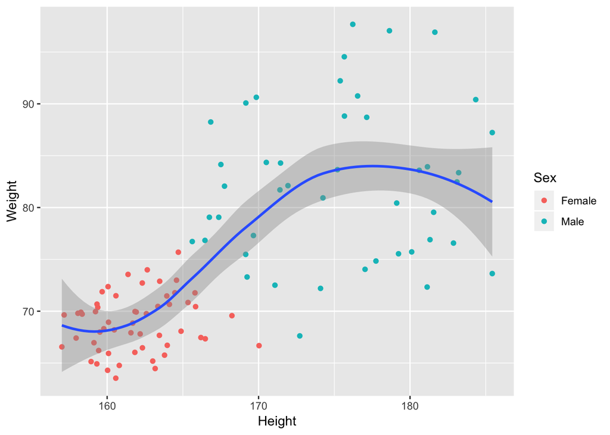

```r
ggplot(data = patients, mapping = aes(x = Height, y = Weight)) +
  geom_point(mapping = aes(colour = Sex)) +
  geom_smooth()
```

Or if you have got your scatter plot just right, and you’d rather not interfere with it while trying out adding another layer, you can use set the `inherit.aes` option to `FALSE`.

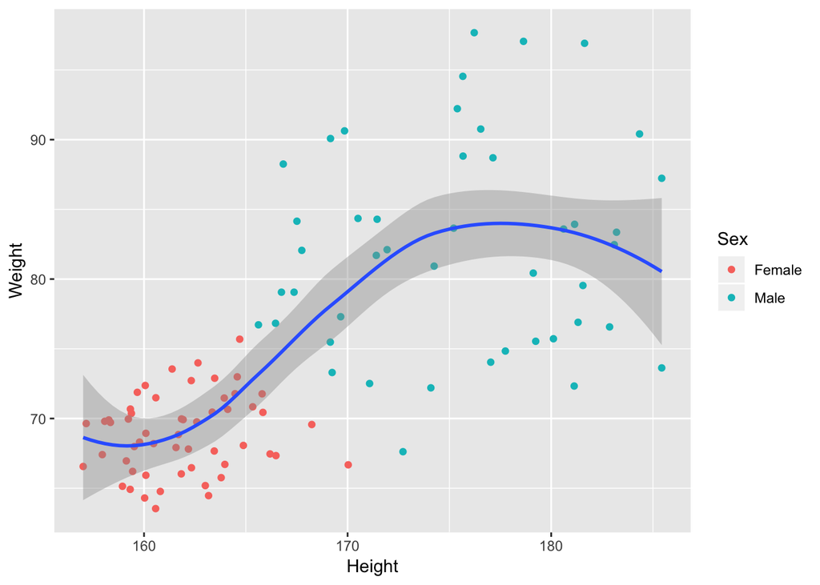

```r
ggplot(data = patients, mapping = aes(x = Height, y = Weight, colour = Sex)) +
  geom_point() +
  geom_smooth(mapping = aes(x = Height, y = Weight), inherit.aes = FALSE)
```

## Some other plot types (geoms)

Let’s explore some other types of plots.

### Line plot

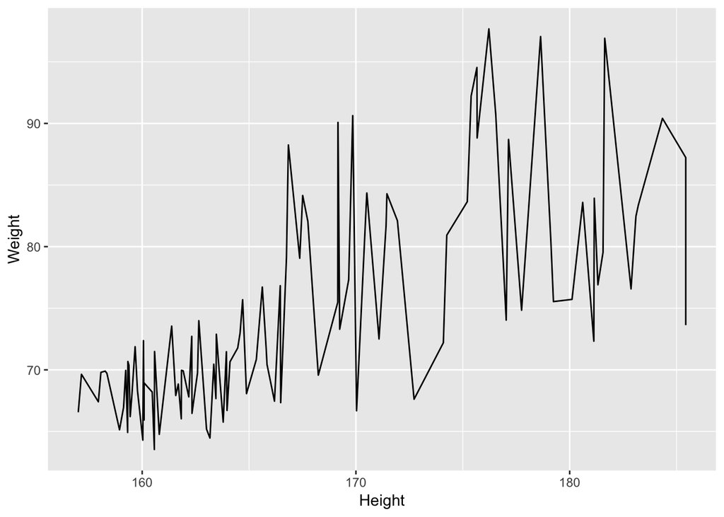

```r
ggplot(data = patients, mapping = aes(x = Height, y = Weight)) +
  geom_line()
```

Doesn’t make much sense for this dataset but good for time series data.

Use multiple geoms (layering) to have both points and lines.

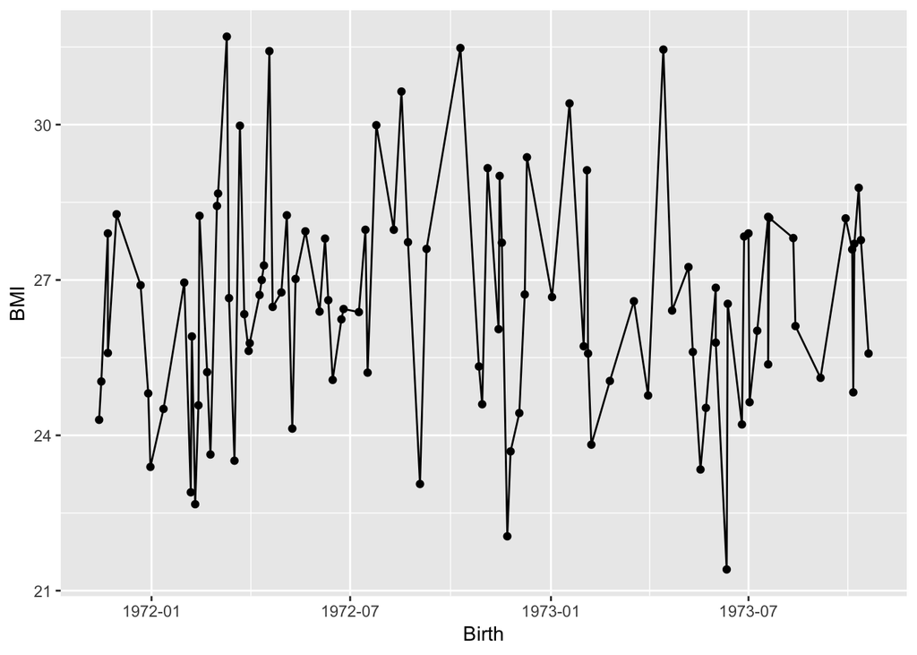

```r
ggplot(data = patients, mapping = aes(x = Birth, y = BMI)) +
  geom_point() +
  geom_line()
```

ggplot2 seems to be doing something clever with dates here.

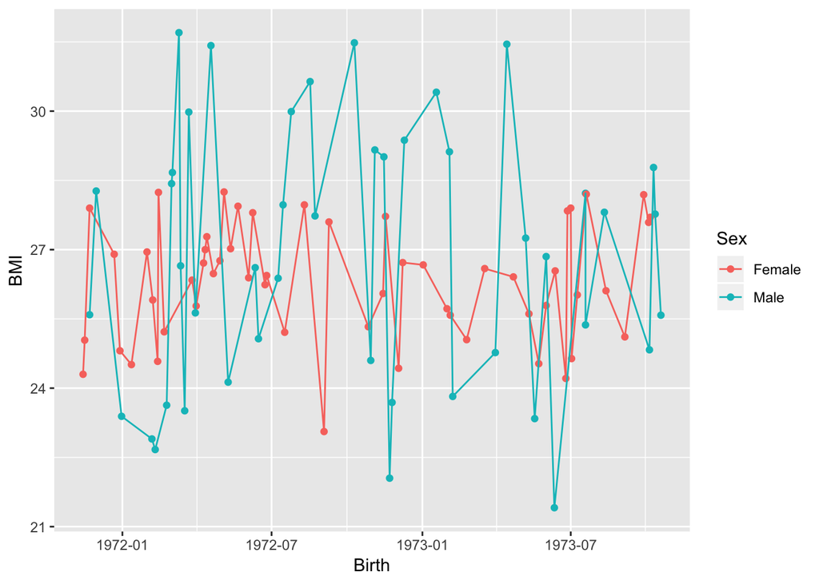

```r
ggplot(data = patients, mapping = aes(x = Birth, y = BMI, colour = Sex)) +
  geom_point() +
  geom_line()
```

### Histogram

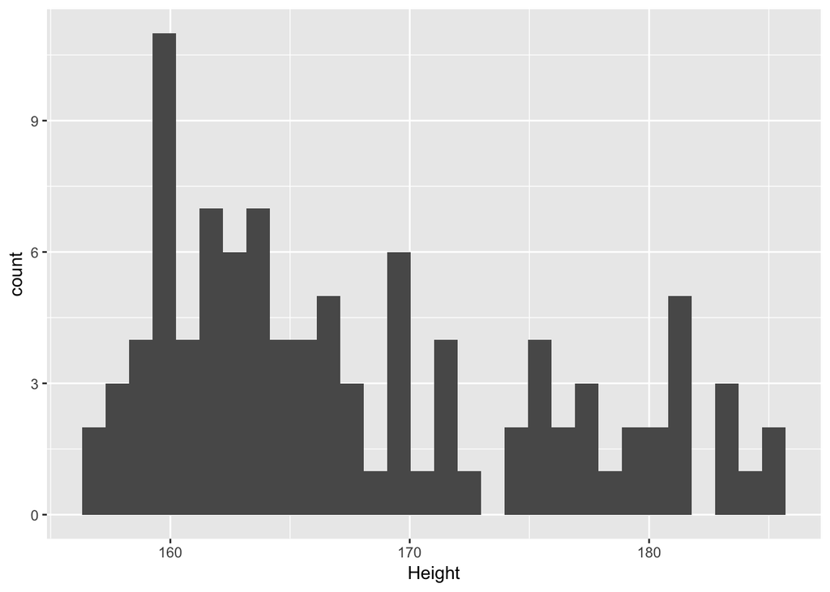

```r
ggplot(data = patients) +
  geom_histogram(mapping = aes(x = Height))
```

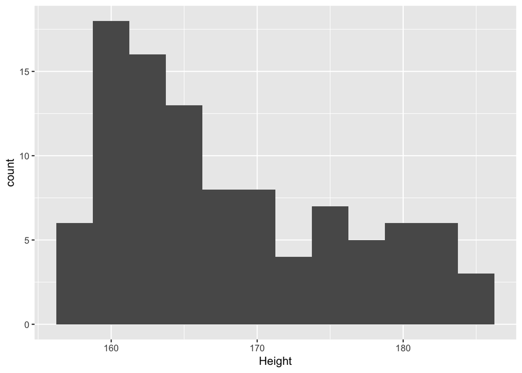

```r
ggplot(data = patients) +
  geom_histogram(mapping = aes(x = Height), binwidth = 2.5)
```

Or can set the number of bins.

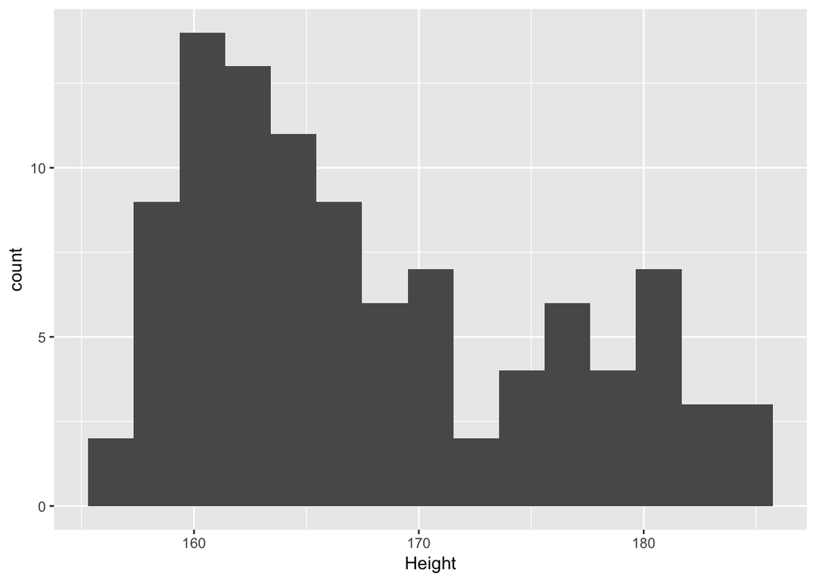

```r
ggplot(data = patients) +
  geom_histogram(mapping = aes(x = Height), bins = 15)
```

These histograms are not aesthetically very pleasing - how about some better aesthetics?

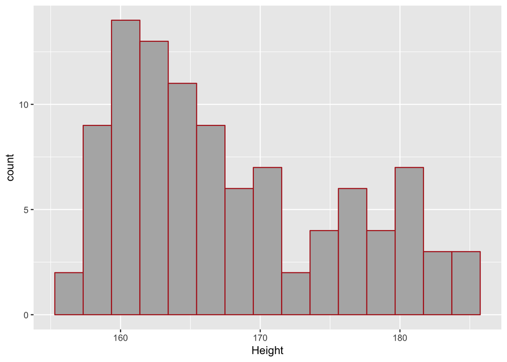

```r
ggplot(data = patients) +
  geom_histogram(mapping = aes(x = Height), bins = 15, colour = "firebrick", fill = "grey70")
```

The help page for geom_histogram talks about an alternative called geom_freqpoly.

*When might this be preferred?*

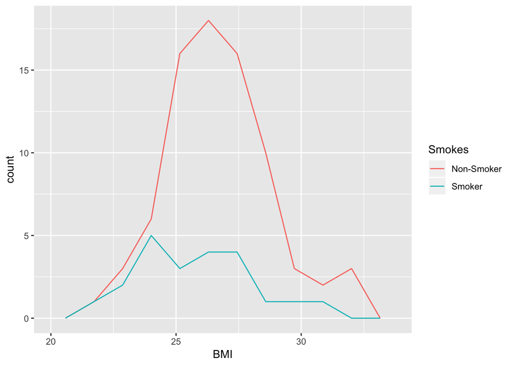

```r
ggplot(data = patients) +
  geom_freqpoly(mapping = aes(x = BMI, colour = Smokes), bins = 10)
```

### Box plot

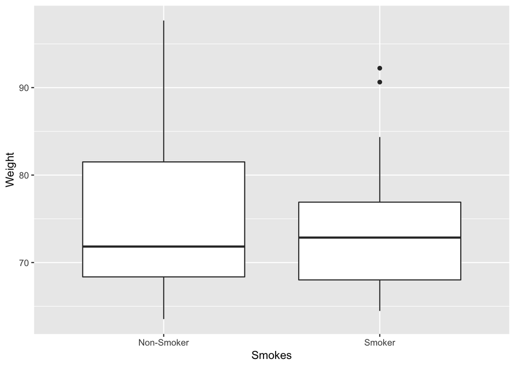

```r
ggplot(data = patients) +
  geom_boxplot(mapping = aes(x = Smokes, y = Weight))
```

See `geom_boxplot` help to explain how the box and whiskers are constructed.

BMI is perhaps a better thing to compare because the Weight is correlated with Height and Sex.

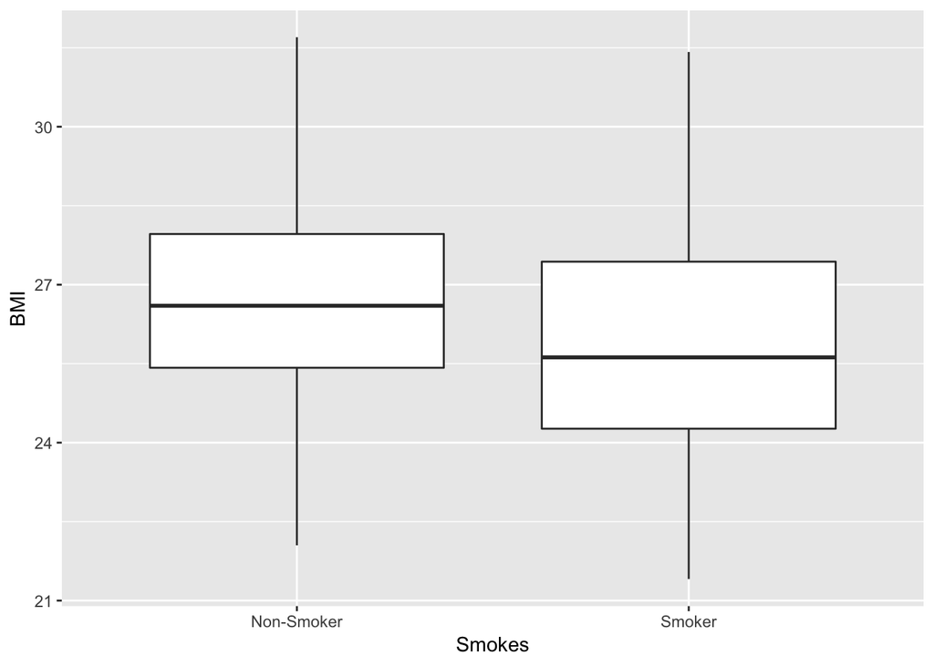

```r
ggplot(data = patients) +
  geom_boxplot(mapping = aes(x = Smokes, y = BMI))
```

Compare males and females separately.

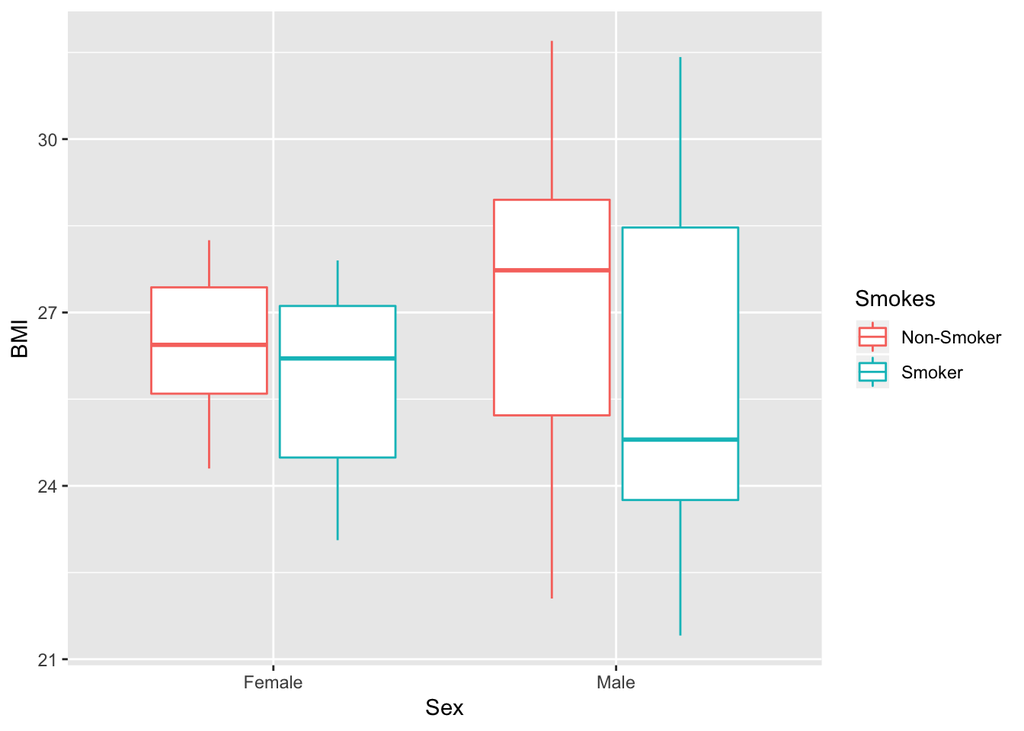

```r
ggplot(data = patients) +
  geom_boxplot(mapping = aes(x = Sex, y = BMI, colour = Smokes))
```

Can we see the points at the same time?

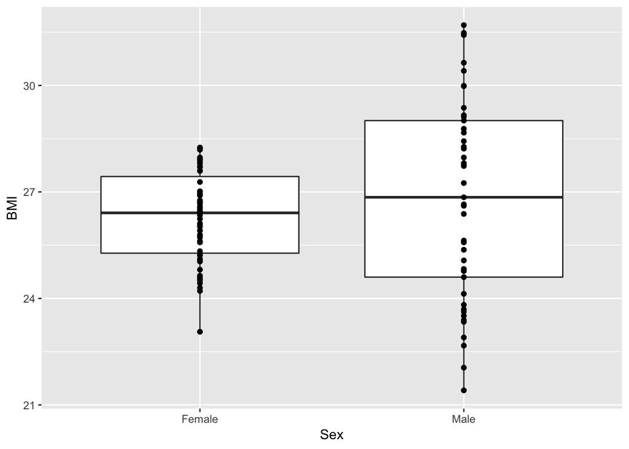

```r
ggplot(data = patients, mapping = aes(x = Sex, y = BMI)) +
  geom_boxplot() +
  geom_point()
```

The `geom_point` help points to `geom_jitter` as more suitable when one of the variables is categorical.

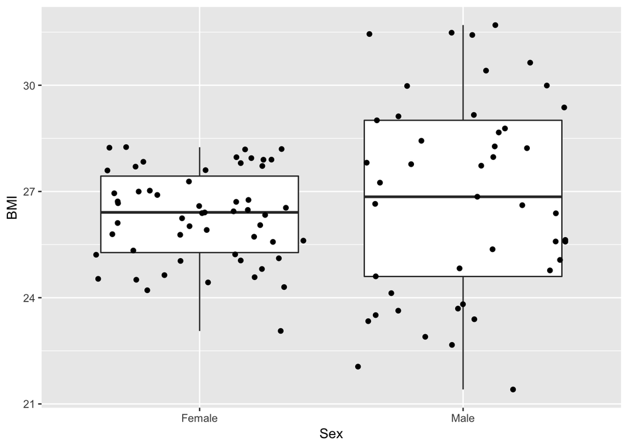

```r
ggplot(data = patients, mapping = aes(x = Sex, y = BMI)) +
  geom_boxplot() +
  geom_jitter()
```

Reduce the spread/jitter.

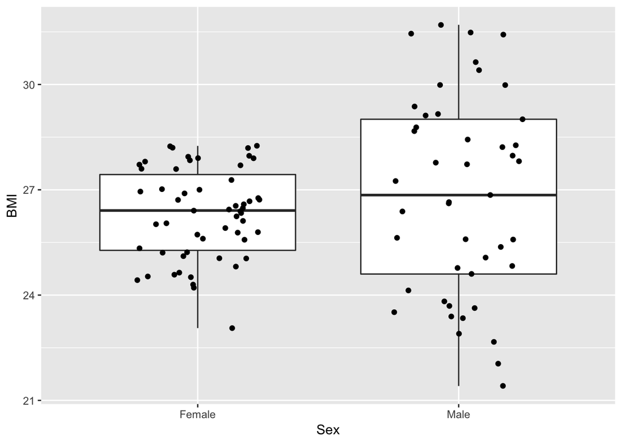

```r
ggplot(data = patients, mapping = aes(x = Sex, y = BMI)) +
  geom_boxplot() +
  geom_jitter(width = 0.25)
```